# Explore and Summarize Data of red wine

# Final Plots and Summary

### Plot One

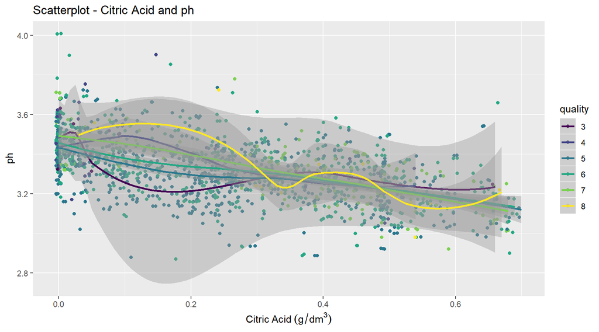

### Description One

This plot illustrates that there was little to no correlation between wine quality and pH. At the same time, there a trend where more highly rated wines tend to be grouped at higher Citric Acid values. However, the trend is far from definite. There are very highly rated wines at low citric acid values as well as very lowely rated wines at high citric acid values.

### Plot Two

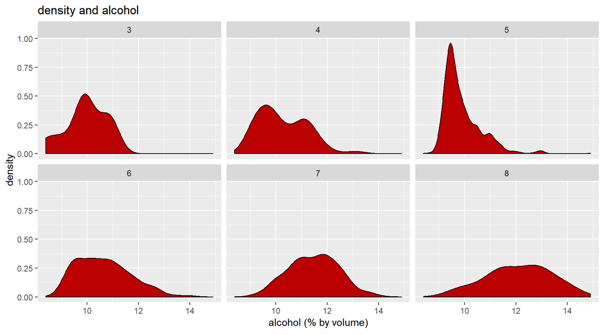

### Description Two

I think paints the most complete picture of the analysis of wine quality with two takeaways.

This visualization was especially appealing to me because of the way that you can almost see the distribution shuffle from left to right as wine ratings increase. Again, just showing a general tendancy instead of a strong correlation.

### Plot Three

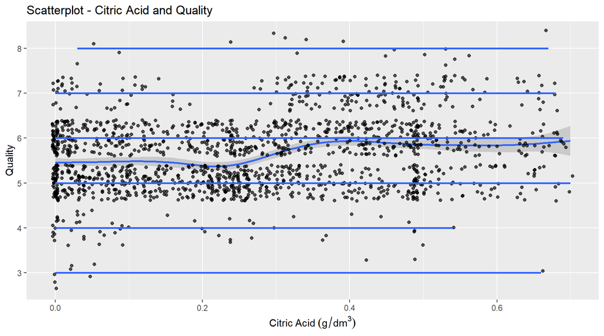

# Reflection

The other variables showed either a Positively skewed or a Normal Distribution.

First I plotted different variables against the quality to see Univariate relationships between them and then one by one I threw in one or more external factors to see if they together have any effect on the categorical variable. I saw that the factors which affected the quality of the wine the most were Alcohol percentage, Sulphate and Acid concentrations.

In the final part of my analysis, I plotted multivariate plots to see if there were some interesting combinations of variables which together affected the overall quality of the wine. It was in this section I found out that density did not play a part in improving wine quality.

For future analysis, I would love to have a dataset, where apart from the wine quality, a rank is given for that particular wine by 10 different wine tasters as we know when we include the human element, our opinion changes on so many different factors. So by including the human element in my analysis, I would be able to put in that perspective and see a lot of unseen factors which might result in a better or worse wine quality. Having these factors included inside the dataset would result in a different insight altogether in my analysis.

# References

https://s3.amazonaws.com/udacity-hosted-downloads/ud651/wineQualityInfo.txt

https://ggplot2.tidyverse.org/reference/index.html